# Exercise 3: tapply and sapply

# Name: Zach Fan

# Date: 11/3/26

# Load state data

```r
data(state)
```

# this data is stored in a slightly different way than other datasets we’ve used so far

# run this line of code to avoid later confusion

```r
states = as.data.frame(state.x77)
```

# 1: What is the average population, income, and area of all 50 states ins the `states` dataset?

# Your code here:

```r
colMeans(states[, c("Population", "Income", "Area")])
```

```
## Population     Income       Area
##    4246.42    4435.80   70735.88
```

# 2. What is the average area of the states from different regions of the country?

# Hint: use the object state.region in your environment

# Your code here:

```r
tapply(states$Area, state.region, mean)
```

```
##     Northeast         South North Central          West
##      18141.00      54605.12      62652.00     134463.00
```

# 3. Plot a histogram for each column in the states data (Population, Income, Illiteracy etc.)

# Your code here:

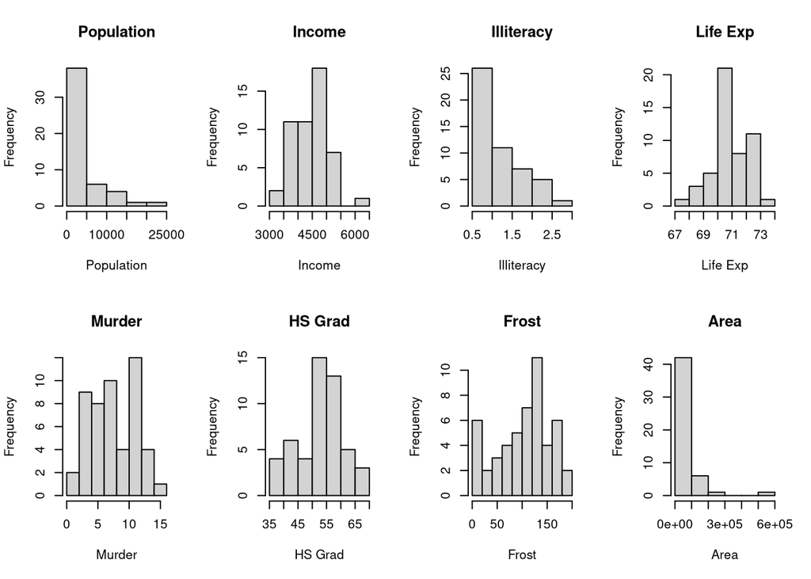

```r
par(mfrow = c(2, 4))
for (col in names(states)) {hist(states[[col]], main = col, xlab = col)}
```

```r
par(mfrow = c(1, 1))
```

# 4. Let’s assume that we don’t want to live in a state with high illiteracy, high murder, and

# many freezing days; also assume that each of these factors contribute equally to our opinion

# (Illiteracy * Murder * Frost) = undesirable

# What 10 states should we avoid? # hint use prod(); and maybe order()

# Your code here:

```r
undesirable <- apply(states[, c("Illiteracy", "Murder", "Frost")], 1, prod)
states[order(undesirable, decreasing = TRUE)[1:10], ]
```

```
##                Population Income Illiteracy Life Exp Murder HS Grad Frost
## Alaska                365   6315        1.5    69.31   11.3    66.7   152
## New Mexico           1144   3601        2.2    70.32    9.7    55.2   120
## South Carolina       2816   3635        2.3    67.96   11.6    37.8    65
## Georgia              4931   4091        2.0    68.54   13.9    40.6    60
## Kentucky             3387   3712        1.6    70.10   10.6    38.5    95
## North Carolina       5441   3875        1.8    69.21   11.1    38.5    80
## Mississippi          2341   3098        2.4    68.09   12.5    41.0    50
## Tennessee            4173   3821        1.7    70.11   11.0    41.8    70
## New York            18076   4903        1.4    70.55   10.9    52.7    82
## Michigan             9111   4751        0.9    70.63   11.1    52.8   125
##                  Area
## Alaska         566432
## New Mexico     121412
## South Carolina  30225
## Georgia         58073
## Kentucky        39650
## North Carolina  48798
## Mississippi     47296
## Tennessee       41328
## New York        47831
## Michigan        56817
```

# 5. Use sapply() to plot a histogram of the data below 4 times, in 4 different colors.

# For extra style, title the plot by it’s color, e.g. the red plot is titled “red”

# Your code here:

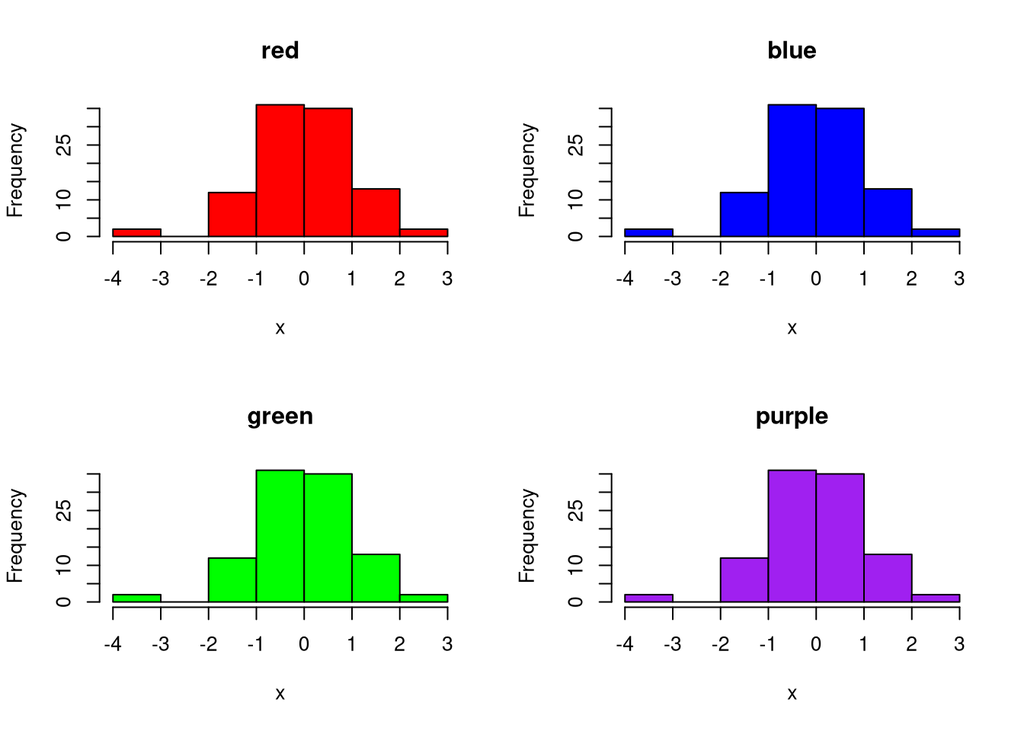

```
##          red       blue      green     purple
## breaks   numeric,8 numeric,8 numeric,8 numeric,8
## counts   integer,7 integer,7 integer,7 integer,7
## density  numeric,7 numeric,7 numeric,7 numeric,7
## mids     numeric,7 numeric,7 numeric,7 numeric,7
## xname    "x"       "x"       "x"       "x"
## equidist TRUE      TRUE      TRUE      TRUE
```

```r
x <- rnorm(100)   # replace with the data from your worksheet

par(mfrow = c(2, 2))
sapply(c("red", "blue", "green", "purple"), function(color) {
  hist(x, col = color, main = color)
})
```

```r
par(mfrow = c(1, 1))
```

# 6. Standardize all the variables in the states dataset and save your answer to a new

# dataframe, states_standardized

# Hint: to standardize a variable, you subtract the mean and divide by the standard deviation (sd)

# Your code here:

```r
states_standardized <- as.data.frame(sapply(states, function(x) (x - mean(x)) / sd(x)))
states_standardized
```

```
##     Population      Income Illiteracy     Life Exp       Murder     HS Grad
## 1  -0.14143156 -1.32113867   1.525758 -1.362193670  2.091810096 -1.46192933
## 2  -0.86939802  3.05824562   0.541398 -1.168509784  1.062429318  1.68280347
## 3  -0.45568908  0.15330286   1.033578 -0.244786635  0.114315444  0.61805142
## 4  -0.47853603 -1.72148373   1.197638 -0.162843452  0.737361704 -1.63526106
## 5   3.79697895  1.10371551  -0.114842  0.619341473  0.791539640  1.17518912
## 6  -0.38199648  0.72940916  -0.771082  0.880069781 -0.156574234  1.33614002
## 7  -0.25678625  1.48453153  -0.114842  1.192943751 -1.158866044  0.35805383
## 8  -0.82146423  0.60735274  -0.442962 -0.609806266 -0.319108041  0.18472210
## 9   0.90280832  0.61711725   0.213278 -0.162843452  0.899895511 -0.06289466
## 10  0.15333885 -0.56113404   1.361698 -1.742112063  1.766742482 -1.54859519
## 11 -0.75673121  0.85797525   1.197638  2.027274338 -0.319108041  1.08852326
## 12 -0.76905064 -0.51556631  -0.935142  0.738531557 -0.562908752  0.79138315
## 13  1.55685818  1.09232357  -0.442962 -0.550211224  0.791539640 -0.06289466
## 14  0.23890291  0.03612870  -0.771082  0.001042913 -0.075307331 -0.02575214
```

[output cut: 87 more lines]

# 7. Create a histogram again for each variable in the states data, but this time label each

# histogram with the variable names when you plot

# Hint: instead of using apply to iterate over the columns themselves, you can often iterate

# over the column names with sapply

# Your code here:

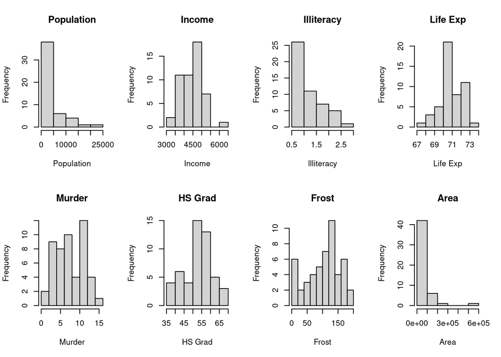

```r
par(mfrow = c(2, 4))
invisible(sapply(names(states), function(name) {
  hist(states[[name]], main = name, xlab = name)
}))
```

```r
par(mfrow = c(1, 1))
```